# Demostration of the Weather model

Andreas Angourakis

07 April, 2021

## Load source file

```r
source("source/weatherModel.R")
```

## Base generic functions

### Sinusoidal curve with fluctuations

Generic function for geting points in sinusoidal curves depending on minValue, maxValue, length of year in days, and a normal stochastic fluctuation. See extended explanation at [HTML with R walkthrough](https://htmlpreview.github.io/?https://github.com/Andros-Spica/indus-village-model/blob/master/01-weather/documentation/annualSinusoidCurve.html).

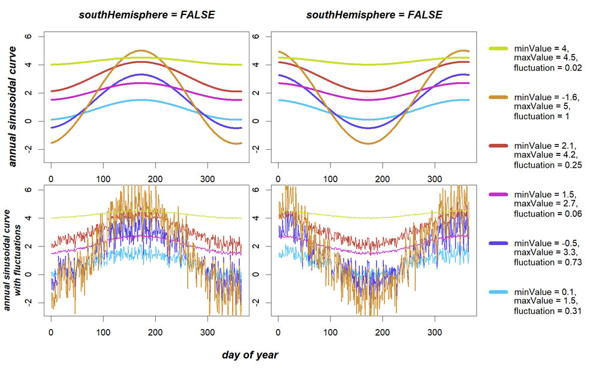

```r
knitr::include_graphics("annualSinusoidCurve_full.png")
```

### Annual cumulative daily precipitation using escalonated double logistic curve

Generic function for geting an year of daily precipitation. First, it generates a double logistic curve of range 0-1 depending on start and end days of year, a plateau value (intermediate value), and two sets of point of inflection and growth rate. See extended explanation at [HTML with R walkthrough](https://htmlpreview.github.io/?https://github.com/Andros-Spica/indus-village-model/blob/master/01-weather/documentation/doubleLogisticCurve.html). Then, the curve is broken down stochastically into steps, controlled by `nSample` and `maxSampleSize`, which better represents the discretionality of precipitation events. Finally, the cumulative daily value is transformed into daily increments, which is multiplied by the annualSum, returning daily precipitation values.

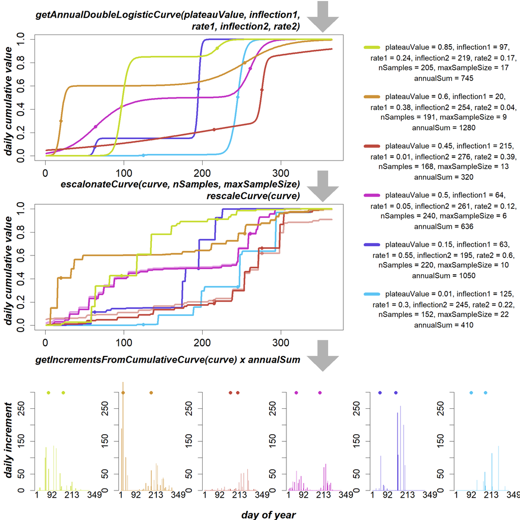

```r
knitr::include_graphics("annualDoubleLogisticCurve_full.png")
```

### Reference evapotranspiration

```r
estimateETr
```

```
## function (R_s, temperature, temperature_max, temperature_min,
##     temperature_dew = temperature_min, windSpeed = 2, albedo = 0.23,
##     z = 200, lambda = 2.45, c_p = 1.013 * 10^-3, epsilon = 0.622,
##     method = "PM", C_n = 900, C_d = 0.34, alpha = 1.26)
## {
##     ETr <- NULL
##     netSolarRadiation <- (1 - albedo) * R_s
##     e_o <- function(temperature) {
##         return(0.6108 * exp(17.27 * temperature/(temperature +
##             237.3)))
##     }
##     e_s = (e_o(temperature_max) + e_o(temperature_min))/2
##     e_a = e_o(temperature_dew)
##     DELTA = 4098 * e_o(temperature)/(temperature + 237.3)^2
##     P = 101.3 * ((293 - 0.0065 * z)/293)^5.26
##     gamma = c_p * P/(epsilon * lambda)
##     if (method == "PM") {
##         ETr <- (0.408 * DELTA * netSolarRadiation + gamma * (C_n/(temperature +
##             273)) * windSpeed * (e_s - e_a))/(DELTA + gamma *
##             (1 + C_d * windSpeed))
##     }
##     if (method == "PT") {
##         ETr <- (alpha/lambda) * (DELTA/(DELTA + gamma)) * netSolarRadiation
##     }
##     return(ETr)
## }
```

```r
#knitr::include_graphics("XXXXXX.png")
```

## Auxiliar functions

An auxiliar function to simplify code with long variable names:

```r
getLastItemInVector
```

```
## function (x)
## {
##     return(x[length(x)])
## }
```

Function for marking the end of each year:

```r
markEndYears
```

```
## function (lengthOfData, offset = 1, yearLengthInDays = 365, lty = 3)
## {
##     for (i in 1:lengthOfData) {
##         if (i%%(yearLengthInDays * offset) == 0) {
##             abline(v = i, lty = lty)
##         }
##     }
## }
```

## The model main procedures

```r
weatherModel.init
```

```
## function (yearLengthInDays = 365, seed = 0, albedo = 0.4, southHemisphere = FALSE,
##     temperature_annualMaxAt2m = 40, temperature_annualMinAt2m = 15,
##     temperature_meanDailyFluctuation = 5, temperature_dailyLowerDeviation = 5,
##     temperature_dailyUpperDeviation = 5, solar_annualMax = 7,
##     solar_annualMin = 3, solar_meanDailyFluctuation = 1, precip_yearlyMean = 400,
##     precip_yearlySd = 130, precip_nSamples = 200, precip_maxSampleSize = 10,
##     precip_plateauValue_yearlyMean = 0.1, precip_plateauValue_yearlySd = 0.05,
##     precip_inflection1_yearlyMean = 40, precip_inflection1_yearlySd = 20,
##     precip_rate1_yearlyMean = 0.15, precip_rate1_yearlySd = 0.02,
##     precip_inflection2_yearlyMean = 200, precip_inflection2_yearlySd = 20,
##     precip_rate2_yearlyMean = 0.05, precip_rate2_yearlySd = 0.01)
## {
##     set.seed(seed)
##     weatherModel <- list()
##     weatherModel$PARS <- list(seed = seed, yearLengthInDays = yearLengthInDays,
##         albedo = albedo, southHemisphere = southHemisphere, temperature = list(annualMaxAt2m = temperature_annualMaxAt2m,
##             annualMinAt2m = temperature_annualMinAt2m, meanDailyFluctuation = temperature_meanDailyFluctuation,
##             dailyLowerDeviation = temperature_dailyLowerDeviation,
##             dailyUpperDeviation = temperature_dailyUpperDeviation),
##         solar = list(annualMax = solar_annualMax, annualMin = solar_annualMin,
##             meanDailyFluctuation = solar_meanDailyFluctuation),
##         precipitation = list(yearlyMean = precip_yearlyMean,
##             yearlySd = precip_yearlySd, nSamples = precip_nSamples,
##             maxSampleSize = precip_maxSampleSize, plateauValue_yearlyMean = precip_plateauValue_yearlyMean,
##             plateauValue_yearlySd = precip_plateauValue_yearlySd,
##             inflection1_yearlyMean = precip_inflection1_yearlyMean,
##             inflection1_yearlySd = precip_inflection1_yearlySd,
##             rate1_yearlyMean = precip_rate1_yearlyMean, rate1_yearlySd = precip_rate1_yearlySd,
##             inflection2_yearlyMean = precip_inflection2_yearlyMean,
##             inflection2_yearlySd = precip_inflection2_yearlySd,
##             rate2_yearlyMean = precip_rate2_yearlyMean, rate2_yearlySd = precip_rate2_yearlySd))
##     weatherModel$annualPrecipitationPars <- list(annualSum = c(),
##         plateauValue = c(), inflection1 = c(), rate1 = c(), inflection2 = c(),
##         rate2 = c())
##     weatherModel$daily <- list(currentYear = c(), currentDayOfYear = c(),
##         temperature = c(), temperature_max = c(), temperature_min = c(),
##         solarRadiation = c(), ETr = c(), precipitation = c())
##     return(weatherModel)
## }
```

```r
weatherModel.run
```

```
## function (weatherModel, numberOfYears)
## {
##     for (year in 1:numberOfYears) {
##         weatherModel$annualPrecipitationPars$annualSum <- c(weatherModel$annualPrecipitationPars$annualSum,
##             max(0, rnorm(1, weatherModel$PARS$precipitation$yearlyMean,
##                 weatherModel$PARS$precipitation$yearlySd)))
##         weatherModel$annualPrecipitationPars$plateauValue <- c(weatherModel$annualPrecipitationPars$plateauValue,
##             min(1, max(0, rnorm(1, weatherModel$PARS$precipitation$plateauValue_yearlyMean,
##                 weatherModel$PARS$precipitation$plateauValue_yearlySd))))
##         weatherModel$annualPrecipitationPars$inflection1 <- c(weatherModel$annualPrecipitationPars$inflection1,
##             min(weatherModel$PARS$yearLengthInDays, max(1, rnorm(1,
##                 weatherModel$PARS$precipitation$inflection1_yearlyMean,
##                 weatherModel$PARS$precipitation$inflection1_yearlySd))))
##         weatherModel$annualPrecipitationPars$rate1 <- c(weatherModel$annualPrecipitationPars$rate1,
##             max(0, rnorm(1, weatherModel$PARS$precipitation$rate1_yearlyMean,
##                 weatherModel$PARS$precipitation$rate1_yearlySd)))
##         weatherModel$annualPrecipitationPars$inflection2 <- c(weatherModel$annualPrecipitationPars$inflection2,
##             min(weatherModel$PARS$yearLengthInDays, max(1, rnorm(1,
##                 weatherModel$PARS$precipitation$inflection2_yearlyMean,
##                 weatherModel$PARS$precipitation$inflection2_yearlySd))))
##         weatherModel$annualPrecipitationPars$rate2 <- c(weatherModel$annualPrecipitationPars$rate2,
##             max(0, rnorm(1, weatherModel$PARS$precipitation$rate2_yearlyMean,
##                 weatherModel$PARS$precipitation$rate2_yearlySd)))
##         weatherModel$daily$precipitation <- c(weatherModel$daily$precipitation,
##             getPrecipitationOfYear(plateauValue = getLastItemInVector(weatherModel$annualPrecipitationPars$plateauValue),
##                 inflection1 = getLastItemInVector(weatherModel$annualPrecipitationPars$inflection1),
##                 rate1 = getLastItemInVector(weatherModel$annualPrecipitationPars$rate1),
##                 inflection2 = getLastItemInVector(weatherModel$annualPrecipitationPars$inflection2),
##                 rate2 = getLastItemInVector(weatherModel$annualPrecipitationPars$rate2),
##                 yearLengthInDays = weatherModel$PARS$yearLengthInDays,
##                 nSamples = weatherModel$PARS$precipitation$nSamples,
##                 maxSampleSize = weatherModel$PARS$precipitation$maxSampleSize,
##                 annualSum = getLastItemInVector(weatherModel$annualPrecipitationPars$annualSum),
##                 seed = runif(1, 0, 2147483647)))
##         for (day in 1:weatherModel$PARS$yearLengthInDays) {
##             weatherModel$daily$currentYear <- c(weatherModel$daily$currentYear,
##                 year)
##             weatherModel$daily$currentDayOfYear <- c(weatherModel$daily$currentDayOfYear,
##                 day)
##             weatherModel$daily$temperature <- c(weatherModel$daily$temperature,
```

[output cut: 13 more lines]

```
##                 max(0, getDayValueInAnnualSinusoidWithFluctuation(minValue = weatherModel$PARS$solar$annualMin,
##                   maxValue = weatherModel$PARS$solar$annualMax,
##                   fluctuation = weatherModel$PARS$solar$meanDailyFluctuation,
##                   dayOfYear = day, yearLengthInDays = weatherModel$PARS$yearLengthInDays,
##                   southHemisphere = weatherModel$PARS$southHemisphere,
##                   seed = runif(1, 0, 2147483647))))
##             weatherModel$daily$ETr <- c(weatherModel$daily$ETr,
##                 estimateETr(R_s = getLastItemInVector(weatherModel$daily$solarRadiation),
##                   temperature = getLastItemInVector(weatherModel$daily$temperature),
##                   temperature_max = getLastItemInVector(weatherModel$daily$temperature_max),
##                   temperature_min = getLastItemInVector(weatherModel$daily$temperature_min)))
##         }
##     }
##     return(weatherModel)
## }
```

# Running the model

## Initialise

```r
weatherModel <- weatherModel.init()
```

Show table with parameter values:

```r
parvalues <- c(
  weatherModel$PARS[[1]],
  weatherModel$PARS[[2]],
  weatherModel$PARS[[3]],
  weatherModel$PARS[[4]]
)
parNames <- c("seed", "yearLengthInDays", "albedo", "southHemisphere")

for (j in 5:length(weatherModel$PARS))
{
  parGroupName <- names(weatherModel$PARS)[j]
  for (i in 1:length(weatherModel$PARS[[j]]))
  {
    parvalues <- c(
      parvalues,
      weatherModel$PARS[[j]][[i]]
    )
    parName <- paste(parGroupName, names(weatherModel$PARS[[j]])[i], sep = " - ")
    parNames <- c(parNames, parName)
  }
}

parvalues <- cbind(parNames, parvalues)
knitr::kable(parvalues,
             format = "html",
             col.names = c("parameter", "values"),
             align = c("l", "r"))
```

| parameter | values |
| --- | --- |
| seed | 0 |
| yearLengthInDays | 365 |
| albedo | 0.4 |
| southHemisphere | 0 |
| temperature - annualMaxAt2m | 40 |
| temperature - annualMinAt2m | 15 |
| temperature - meanDailyFluctuation | 5 |
| temperature - dailyLowerDeviation | 5 |
| temperature - dailyUpperDeviation | 5 |
| solar - annualMax | 7 |
| solar - annualMin | 3 |
| solar - meanDailyFluctuation | 1 |
| precipitation - yearlyMean | 400 |
| precipitation - yearlySd | 130 |
| precipitation - nSamples | 200 |
| precipitation - maxSampleSize | 10 |
| precipitation - plateauValue_yearlyMean | 0.1 |
| precipitation - plateauValue_yearlySd | 0.05 |
| precipitation - inflection1_yearlyMean | 40 |
| precipitation - inflection1_yearlySd | 20 |
| precipitation - rate1_yearlyMean | 0.15 |
| precipitation - rate1_yearlySd | 0.02 |
| precipitation - inflection2_yearlyMean | 200 |
| precipitation - inflection2_yearlySd | 20 |
| precipitation - rate2_yearlyMean | 0.05 |
| precipitation - rate2_yearlySd | 0.01 |

## Run

Run for 5 years:

```r
set.seed(0)
weatherModel <- weatherModel.run(weatherModel, numberOfYears = 5)
```

## 0.1 Plot results

Set colours for maximum and minimum temperature:

```r
maxTemperatureColour = hsv(7.3/360, 74.6/100, 70/100)

minTemperatureColour = hsv(232/360, 64.6/100, 73/100)
```

Plot time-series:

```r
lengthOfSimulation = length(weatherModel$daily$currentYear)

#--------
plotName = "weatherModelExample.png"

grScale = 2
fontRescale = 0
fontRescaleDay = 0

png(plotName, width = grScale * 600, height = grScale * 700)
#---------
# alternatively, to create eps file:
#---------
# plotName = "FigX-weatherModelExample.eps"
#
# grScale = 1.2
# fontRescale = 0.1
# fontRescaleDay = -0.5 # to adjust unexpected scale behaviour in mtext
#
# extrafont::loadfonts(device = "postscript")
# grDevices::cairo_ps(file = plotName,
#                       pointsize = 12,
#                       width = grScale * 6,
#                       height = grScale * 7,
#                       onefile = FALSE,
#                       family = "sans")
#---------

layout(matrix(c(1:10),
              nrow = 5, ncol = 2, byrow = FALSE),
       widths = c(1, 10),
       heights = c(10, 10, 10, 12, 2))

yLabs <- c(expression(paste("    Solar\nRadiation (", MJ/m^-2, ")")),
           "Temperature (C)",
           "ETr (mm)",
           "Precipitation (mm)")

par(cex = grScale)

# First column

par(mar = c(0, 0, 0, 0))

plot(c(0, 1), c(0, 1), ann = F, bty = 'n', type = 'n', xaxt = 'n', yaxt = 'n')
text(x = 0.5, y = 0.5, font = 4,
     cex = grScale * (0.6 + fontRescale),
     srt = 90,
     labels = yLabs[1])

plot(c(0, 1), c(0, 1), ann = F, bty = 'n', type = 'n', xaxt = 'n', yaxt = 'n')
text(x = 0.5, y = 0.5, font = 4,
     cex = grScale * (0.7 + fontRescale),
     srt = 90,
     labels = yLabs[2])

plot(c(0, 1), c(0, 1), ann = F, bty = 'n', type = 'n', xaxt = 'n', yaxt = 'n')
text(x = 0.5, y = 0.6, font = 4,
     cex = grScale * (0.7 + fontRescale),
     srt = 90,
     labels = yLabs[3])

plot(c(0, 1), c(0, 1), ann = F, bty = 'n', type = 'n', xaxt = 'n', yaxt = 'n')
text(x = 0.5, y = 0.6, font = 4,
     cex = grScale * (0.7 + fontRescale),
     srt = 90,
     labels = yLabs[4])

plot(c(0, 1), c(0, 1), ann = F, bty = 'n', type = 'n', xaxt = 'n', yaxt = 'n')

# Second column

par(mar = c(0.2, 1, 0.5, 0.1),
    cex.axis = grScale * (0.6 + fontRescale))

# 1: Solar radiation
plot(1:lengthOfSimulation, weatherModel$daily$solarRadiation, type = "l",
     xlab = "", xaxt = 'n',
     ylab = "")
markEndYears(lengthOfSimulation)

# 2: Temperature
plot(1:lengthOfSimulation, weatherModel$daily$temperature, type = "l",
     xlab = "", xaxt = 'n',
     ylab = "")
lines(1:lengthOfSimulation, weatherModel$daily$temperature_max,
      col = adjustcolor(maxTemperatureColour, alpha.f = 0.8))
lines(1:lengthOfSimulation, weatherModel$daily$temperature_min,
      col = adjustcolor(minTemperatureColour, alpha.f = 0.8))

markEndYears(lengthOfSimulation)

# 3: Reference evapotranspiration

plot(1:lengthOfSimulation, weatherModel$daily$ETr, type = "l",
     ylab = "",
     xlab = "", xaxt = 'n')
markEndYears(lengthOfSimulation)

# 4: Precipitation
par(mar = c(2, 1, 0.1, 0.1))

barplot(weatherModel$daily$precipitation,
        ylab = "",
        #names.arg = 1:lengthOfSimulation,
        xlab = "", xaxt = 'n')
markEndYears(lengthOfSimulation
             , offset = 1.2)
abline(v = lengthOfSimulation * 1.2, lty = 3)
# not sure why, but barplot() x coordinates do not behave as in plot()

# 5:  x-axis title

par(mar = c(1, 1, 0, 0.1))

plot(c(1, lengthOfSimulation), c(0, 1), ann = F, bty = 'n', type = 'n', xaxt = 'n', yaxt = 'n')

axis(3,
     at = 1:lengthOfSimulation,
     tck = 0, lwd = 0)

mtext("day", side = 1, line = -1,
      font = 4, cex = grScale * (1.7 + fontRescale + fontRescaleDay))
dev.off()
```

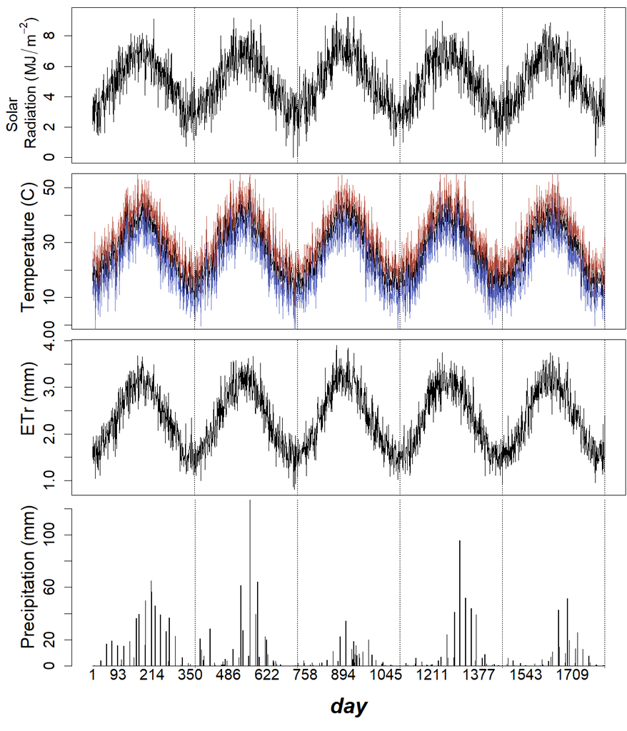

```r
knitr::include_graphics(plotName)
```